# Reproducible research of Activity analisys

## 0. Preparation to analisys

First, before we will start our analisys, we need to adjust our work environment: * attach neede libraries * set working directory

```r
library(lubridate)
library(tidyr)
library(plyr)
library(dplyr)
library(knitr)
```

## 1. Loading and preprocessing the data

Loading the data it self:

```r
setwd("C:\\Documents\\Data analysis\\Projects\\ReproducibleResearch_1")
dat <- read.csv("activity.csv", stringsAsFactors = FALSE, header = TRUE)
```

Lets make our data more suitable for our analisys. Just a few minor transofmation needed. First convert column “date” into correct format:

```r
dat <- mutate(dat, date = ymd(date))
```

## 2. What is mean total number of steps taken per day?

First thing - lets transform our dataset, and leave only needed information. So NA will be deleted and just columns Date and Steps remain:

```r
dat2 <- filter(dat, !is.na(dat$steps))
dat2 <- dat2[,c("date", "steps")]
```

To calculate average number of step per day we have to devide dataset into groups per each day:

```r
dat2 <- group_by(dat2, date)
```

Now we can calculate total amount of steps for each date:

```r
dat2 <- summarize(dat2, sum(steps))
names(dat2) <- c("date", "steps")
```

Now it’s time to build required histogram:

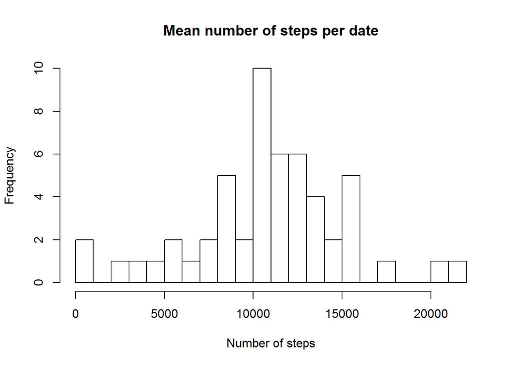

```r
hist(x = dat2$steps,
     breaks = 20,
     main = "Mean number of steps per date",
     xlab = "Number of steps",
     ylab = "Frequency")
```

Another two things will be usefull to know is median and mean number of steps taken per day:

```r
mean(dat2$steps)
```

```
## [1] 10766
```

```r
median(dat2$steps)
```

```
## [1] 10765
```

## 3. What is the average daily activity pattern?

Again, we will remove NA from the dataset and leave only needed variables:

```r
dat3 <- filter(dat, !is.na(dat$steps))
dat3 <- dat3[,c("interval", "steps")]
```

Now we have to count mean of steps per each time interval:

```r
dat3 <- group_by(dat3, interval)
dat3 <- summarize(dat3, mean(steps))
names(dat3) <- c("interval", "steps")
```

Data is transformed properly, now we can get a plot:

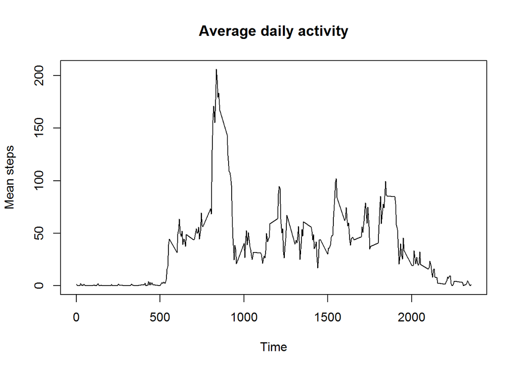

```r
plot(x=dat3$interval,
     y=dat3$steps,
     type="l",
     main="Average daily activity",
     xlab="Time",
     ylab="Mean steps")
```

Let’s get 5-minute interval, which contains the maximum number of stepson average across all the days in the dataset:

```r
dat3[which.max(dat3$steps),]
```

```
## Source: local data frame [1 x 2]
##
##     interval steps
## 104      835 206.2
```

## 4. Inputing missing values

Let’s count how many missing values do we have in our datasets:

```r
dat4 <- dat[is.na(dat$steps),]
length(dat4[,1])
```

```
## [1] 2304
```

In order to have complete dataset without missing values, let’s calculate median of steps per each time interval and put this values intp places where they are missing. So first we calculate medians of steps per each time interval:

```r
med_steps <- filter(dat, !is.na(dat$steps))
med_steps <- med_steps[,c("interval", "steps")]
med_steps <- group_by(med_steps, interval)
med_steps <- summarize(med_steps, median(steps))
names(med_steps) <- c("interval", "steps")
```

Now we can merge initial dataset with median into one dataset:

```r
dat4 <- merge(dat, med_steps, by.x = "interval", by.y = "interval")
```

In the Variable Steps, where the values are missing we will put our medians:

```r
dat4[is.na(dat4$steps.x),"steps.x"] <- dat4[is.na(dat4$steps.x),"steps.y"]
dat4 <- arrange(dat4, date)
dat4$steps.y <- NULL
names(dat4) <- c("interval","steps","date")
```

Time to make histogram:

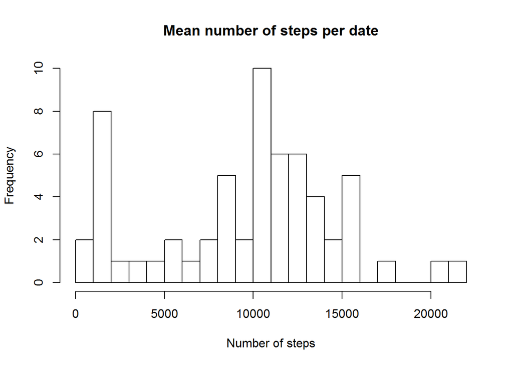

```r
dat4_hist <- dat4[,c("date", "steps")]
dat4_hist <- group_by(dat4_hist, date)
dat4_hist <- summarize(dat4_hist, sum(steps))
names(dat4_hist) <- c("date", "steps")
hist(dat4_hist$steps,
     breaks = 20,
     main = "Mean number of steps per date",
     xlab = "Number of steps",
     ylab = "Frequency")
```

And compare mean and median with the previous results:

```r
mean(dat4_hist$steps)
```

```
## [1] 9504
```

```r
median(dat4_hist$steps)
```

```
## [1] 10395
```

## 5. Are there differences in activity patterns between weekdays and weekends?

In order to compare activity during working days and weekends we will add new variable. If the weekday is Saturday or Sunday - we will concider this as weekends. Also we have to check the names iof weekday in my native language:

```r
dat5 <- mutate(dat4, weekday = weekdays(date, 1))
dat5$daytype <- ifelse(dat5$weekday == 'Сб' | dat5$weekday == 'Нд' |
                         dat5$weekday == 'Sat' | dat5$weekday == 'Sun', "weekend", "weekday")
```

Finally we can prepare data for plotting. Let’s calculate daily activity per time interval for weekdays, and then separately for weekend.

```r
dat5_weekday <- filter(dat5, daytype=="weekday")
dat5_weekday <- group_by(dat5_weekday, interval)
dat5_weekday <- summarize(dat5_weekday, mean(steps))
names(dat5_weekday) <- c("interval", "steps")

dat5_weekend <- filter(dat5, daytype=="weekend")
dat5_weekend <- group_by(dat5_weekend, interval)
dat5_weekend <- summarize(dat5_weekend, mean(steps))
names(dat5_weekend) <- c("interval", "steps")
```

Now we can plot two prepared datasets:

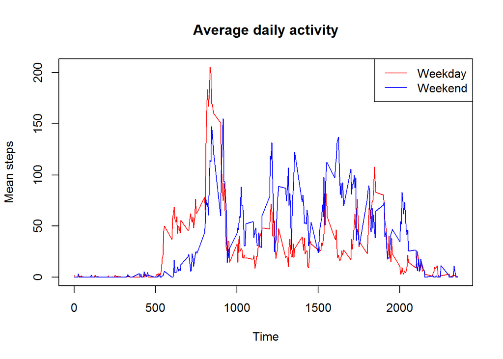

```r
plot(x = dat5_weekday$interval,
     y = dat5_weekday$steps,
     type = "l",
     main = "Average daily activity",
     xlab = "Time",
     ylab = "Mean steps",
     col = "red")

points(x = dat5_weekend$interval,
     y = dat5_weekend$steps,
     type = "l",
     col = "blue")

legend("topright",
       lty = 1,
       legend = c("Weekday", "Weekend"),
       col = c("red", "blue"))
```